# SQL-NoSQL analysis

2. Are higher-educated people more or less likely to default?

```r
#Performing pearson Chi-sq test of independence.
#Null hypothesis: "education level is independent of whether or not someone will default, at the 0.05 significance level."

#First tabulating the contingency table of the two variables
educ_conting=table(credit$EDUCATION, credit$DEFAULT_PAYMENT_NEXT_MONTH)
educ_conting
```

```
##
##                      0     1
##   graduate        8549  2036
##   high school     3680  1237
##   others           116     7
##   under graduate 10700  3330
##   uneducated        14     0
##   unknown          305    26
```

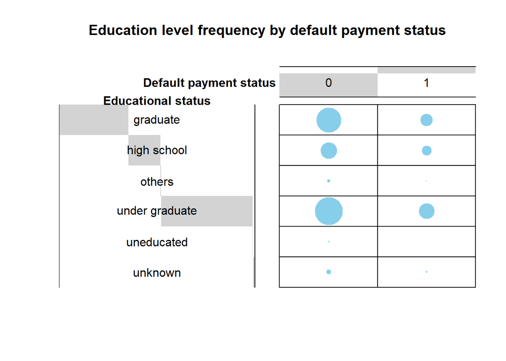

```r
balloonplot(t(educ_conting), main='Education level frequency by default payment status', xlab='Default payment status', ylab='Educational status', label=FALSE, show.margins=FALSE)
```

```r
#This gives the counts of each category in each 'axis' specified

#Chi-squared test
chi_sq_test<-chisq.test(educ_conting)
chi_sq_test
```

```
##
##  Pearson's Chi-squared test
##
## data:  educ_conting
## X-squared = 161.07, df = 5, p-value < 2.2e-16
```

```r
#round(chi_sq_test$expected,2)

#To determine the nature of the dependence between rows (education) and columns (payment status), use chi-sq residuals (Pearson residuals)
chisq_resid<-round(chi_sq_test$residuals,3)
chisq_resid
```

```
##
##                       0      1
##   graduate        3.364 -6.312
##   high school    -2.414  4.529
##   others          2.065 -3.874
##   under graduate -2.167  4.067
##   uneducated      0.938 -1.760
##   unknown         2.941 -5.518
```

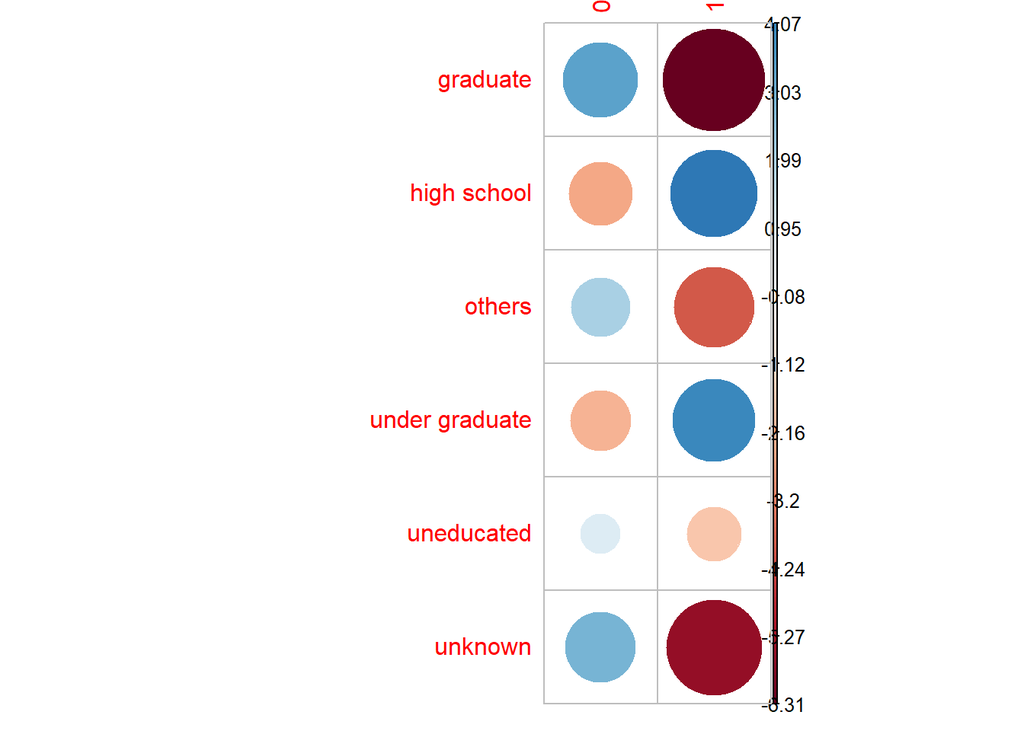

```r
#Visualization of the residuals shows the positive (blue) and negative (red) correlations between the row and column variables.
corrplot(chisq_resid, is.cor=FALSE)
```

The results of the chi square test show that there is a highly significant interaction between education level and probability that someone will default on their credit card bill (p<<<0.05).

We can also see from the chi-squared test and analysis of the residuals in the corrplot that there is a strong positive association between those who defult and those with either a high school or undergraduate education. Meanwhile, defaulting is negatively associated with having a graduate education or ‘uneducated, other, or unknown’ education level.